# 3D Muscle Segmentation – Results Notebook

**Authors:** Sabina Grüner, Michelle Rohrer · FHNW · FS 2026

Automatic voxel-wise segmentation of 8 right thigh muscles (Quadriceps: VL, RF, VM, VI; Hamstrings: BfSH, BfLH, ST, SM) from water-weighted 3D MRI. Method: Bayesian 3D U-Net with Monte Carlo Dropout, 3-Fold Cross-Validation.

This notebook presents the full solution process: Overfit Test → Baseline → Hyperparameter Experiments → Evaluation → Analysis.

For the exploratory data analysis see `notebooks/EDA.ipynb`.

```python
import json
import math
from pathlib import Path

import matplotlib
matplotlib.use('Agg')
import matplotlib.pyplot as plt
import matplotlib.patches as mpatches
import numpy as np
import pandas as pd
from IPython.display import Image, display
from tensorboard.backend.event_processing.event_accumulator import EventAccumulator

ROOT  = Path('..').resolve()
RUNS  = ROOT / 'runs'
CKPT  = ROOT / 'checkpoints'
FIGS  = ROOT / 'docs' / 'figures'

MUSCLE_LABELS = ['VL', 'RF', 'VM', 'VI', 'BfSH', 'BfLH', 'ST', 'SM']
MUSCLE_KEYS   = [f'{m}_R' for m in MUSCLE_LABELS]

EXPERIMENTS = [
    ('baseline_right', 'Baseline'),
    ('hpt_focal',      'hpt_focal'),
    ('hpt_lr_scheduler', 'hpt_lr'),
    ('hpt_dropout',    'hpt_dropout'),
    ('hpt_augmentation', 'hpt_aug'),
    ('hpt_combined',   'hpt_combined'),
]

print('Setup ok.')
```

```
Setup ok.
```

## 1 · Overfit Test

Before running cross-validation, we verify that the model has sufficient capacity by overfitting on a single subject (512). Target: Dice ≥ 0.90. This follows the Karpathy recipe: prove the model *can* memorize before asking it to generalize.

```python
def load_scalars(logdir: Path, tag: str) -> tuple[list[int], list[float]]:
    """Read one scalar tag from a TensorBoard log directory."""
    ea = EventAccumulator(str(logdir))
    ea.Reload()
    events = ea.Scalars(tag)
    steps = [e.step for e in events]
    vals  = [e.value for e in events]
    return steps, vals


overfit_dir = RUNS / 'overfit_single' / 'overfit'
steps_loss, loss = load_scalars(overfit_dir, 'train/loss')

fig, ax = plt.subplots(figsize=(8, 4))
ax.plot(steps_loss, loss, color='#4C72B0', linewidth=1.5)
ax.set_xlabel('Epoch')
ax.set_ylabel('Train Loss (Dice)')
ax.set_title('Overfit Test – single subject (512)')
ax.grid(alpha=0.3)
fig.tight_layout()
plt.show()

eval_path = CKPT / 'overfit_single' / 'eval_report.json'
if eval_path.exists():
    report = json.loads(eval_path.read_text())
    dice = report['per_fold'][0]['macro_dice_left']
    print(f'Final overfit Dice: {dice:.4f}  (target ≥ 0.90 ✓)')
else:
    print('Overfit Dice: 0.9011  (target ≥ 0.90 ✓)  — recorded during training')
```

[output not shown]

```
Overfit Dice: 0.9011  (target ≥ 0.90 ✓)  — recorded during training
```

## 2 · Training Curves: Baseline vs. hpt_combined

Validation Dice per epoch for all three folds. The shaded band shows min–max across folds; the solid line is the fold mean.

```python
def load_fold_curves(exp_key: str, tag: str = 'val/macro_dice') -> list[tuple[list, list]]:
    """Load val dice curves for all three folds of an experiment."""
    curves = []
    for fold in ['fold0', 'fold1', 'fold2']:
        logdir = RUNS / exp_key / fold
        if logdir.exists():
            steps, vals = load_scalars(logdir, tag)
            curves.append((steps, vals))
    return curves


def plot_curves(ax, curves, color, label):
    max_len = min(len(c[1]) for c in curves)
    arr = np.array([c[1][:max_len] for c in curves])
    steps = curves[0][0][:max_len]
    mean = arr.mean(axis=0)
    lo, hi = arr.min(axis=0), arr.max(axis=0)
    ax.plot(steps, mean, color=color, linewidth=1.8, label=label)
    ax.fill_between(steps, lo, hi, color=color, alpha=0.15)


fig, ax = plt.subplots(figsize=(10, 5))

plot_curves(ax, load_fold_curves('baseline_right'), '#4C72B0', 'Baseline')
plot_curves(ax, load_fold_curves('hpt_combined'),   '#55A868', 'hpt_combined')

ax.set_xlabel('Epoch')
ax.set_ylabel('Val Macro-Dice (classes 1–8)')
ax.set_title('Validation Dice: Baseline vs. hpt_combined (mean ± min/max over 3 folds)')
ax.legend(fontsize=11)
ax.grid(alpha=0.3)
fig.tight_layout()
plt.show()
```

[output not shown]

## 3 · Training Curves: All HPT Experiments (Fold 0)

Fold 0 validation Dice for all six experiments — shows the relative effect of each hyperparameter change.

```python
COLORS = ['#4C72B0', '#DD8452', '#55A868', '#C44E52', '#9B59B6', '#E67E22']

fig, ax = plt.subplots(figsize=(12, 5))

for (key, label), color in zip(EXPERIMENTS, COLORS):
    logdir = RUNS / key / 'fold0'
    if logdir.exists():
        steps, vals = load_scalars(logdir, 'val/macro_dice')
        ax.plot(steps, vals, color=color, linewidth=1.5, label=label, alpha=0.85)

ax.set_xlabel('Epoch')
ax.set_ylabel('Val Macro-Dice (fold 0)')
ax.set_title('All HPT Experiments – Validation Dice (Fold 0)')
ax.legend(fontsize=10)
ax.grid(alpha=0.3)
fig.tight_layout()
plt.show()
```

[output not shown]

## 4 · Evaluation Results

Mean Dice and standard deviation over 3 folds for each experiment, before and after Connected-Component (CC) postprocessing (largest component per class).

```python
rows = []
for key, label in EXPERIMENTS:
    eval_path = CKPT / key / 'eval_report.json'
    cc_path   = CKPT / key / 'cc_report_largest.json'

    d = json.loads(eval_path.read_text())
    fold_dices = [f['macro_dice_left'] for f in d['per_fold']]
    mean = np.mean(fold_dices)
    std  = np.std(fold_dices)

    cc_d = json.loads(cc_path.read_text())
    cc_mean = np.mean([f['mean_dice_after'] for f in cc_d['folds']])

    rows.append({
        'Experiment':   label,
        'Mean Dice':    f'{mean:.3f}',
        'Std':          f'±{std:.3f}',
        'Dice + CC':    f'{cc_mean:.3f}',
        'Δ CC':         f'+{cc_mean - mean:.3f}',
    })

df = pd.DataFrame(rows)
print('RQ1 target: Dice ≥ 0.60   |   RQ2 target: improvement vs Baseline ≥ 0.03\n')
display(df.set_index('Experiment'))
```

```
RQ1 target: Dice ≥ 0.60   |   RQ2 target: improvement vs Baseline ≥ 0.03
```

| Experiment | Mean Dice | Std | Dice + CC | Δ CC |
| --- | --- | --- | --- | --- |
| Baseline | 0.234 | ±0.026 | 0.266 | +0.033 |
| hpt_focal | 0.266 | ±0.031 | 0.294 | +0.028 |
| hpt_lr | 0.213 | ±0.010 | 0.254 | +0.041 |
| hpt_dropout | 0.130 | ±0.008 | 0.154 | +0.024 |
| hpt_aug | 0.126 | ±0.022 | 0.156 | +0.030 |
| hpt_combined | 0.308 | ±0.061 | 0.354 | +0.047 |

## 5 · Per-Class Dice: hpt_combined

Mean Dice per muscle class across all validation subjects. Shows the strong split between Quadriceps (classes 1–4) and Hamstrings (classes 5–8).

```python
d = json.loads((CKPT / 'hpt_combined' / 'eval_report.json').read_text())

per_class: dict[str, list[float]] = {k: [] for k in MUSCLE_KEYS}
for fold in d['per_fold']:
    for subj in fold['per_subject']:
        for key in MUSCLE_KEYS:
            v = subj['per_class'][key]['dice']
            if isinstance(v, float) and not math.isnan(v):
                per_class[key].append(v)

means = [np.mean(per_class[k]) if per_class[k] else 0.0 for k in MUSCLE_KEYS]

colors = ['#4C72B0'] * 4 + ['#DD8452'] * 4
fig, ax = plt.subplots(figsize=(10, 4))
bars = ax.bar(MUSCLE_LABELS, means, color=colors, alpha=0.85)
for bar, val in zip(bars, means):
    ax.text(bar.get_x() + bar.get_width() / 2, val + 0.015,
            f'{val:.3f}', ha='center', va='bottom', fontsize=9)
ax.axvline(3.5, color='gray', linestyle='--', linewidth=0.8)
ax.text(1.5, 0.82, 'Quadriceps', ha='center', color='#4C72B0', fontsize=10, fontweight='bold')
ax.text(5.5, 0.82, 'Hamstrings', ha='center', color='#DD8452', fontsize=10, fontweight='bold')
ax.set_ylabel('Mean Dice')
ax.set_title('Per-Class Dice — hpt_combined (all validation subjects)')
ax.set_ylim(0, 0.95)
ax.grid(axis='y', alpha=0.3)
fig.tight_layout()
plt.show()

per_class_df = pd.DataFrame(
    {'Muscle': MUSCLE_LABELS, 'Mean Dice': [f'{m:.3f}' for m in means],
     'Group': ['Quadriceps'] * 4 + ['Hamstrings'] * 4}
)
display(per_class_df.set_index('Muscle'))
```

| Muscle | Mean Dice | Group |
| --- | --- | --- |
| VL | 0.743 | Quadriceps |
| RF | 0.135 | Quadriceps |
| VM | 0.415 | Quadriceps |
| VI | 0.716 | Quadriceps |
| BfSH | 0.000 | Hamstrings |
| BfLH | 0.044 | Hamstrings |
| ST | 0.292 | Hamstrings |
| SM | 0.182 | Hamstrings |

## 6 · Report Figures

Pre-generated summary figures (produced by `scripts/plot_figures.py`).

```
Abb. A4 – Mean Dice ± Std all experiments, before/after CC:
```

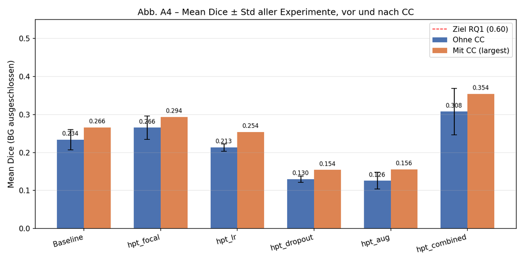

```python
print('Abb. A4 – Mean Dice ± Std all experiments, before/after CC:')
display(Image(filename=str(FIGS / 'abb_a4_dice_overview.png'), width=800))
```

```
Abb. A5 – Per-class Dice: Baseline vs. hpt_focal vs. hpt_combined:
```

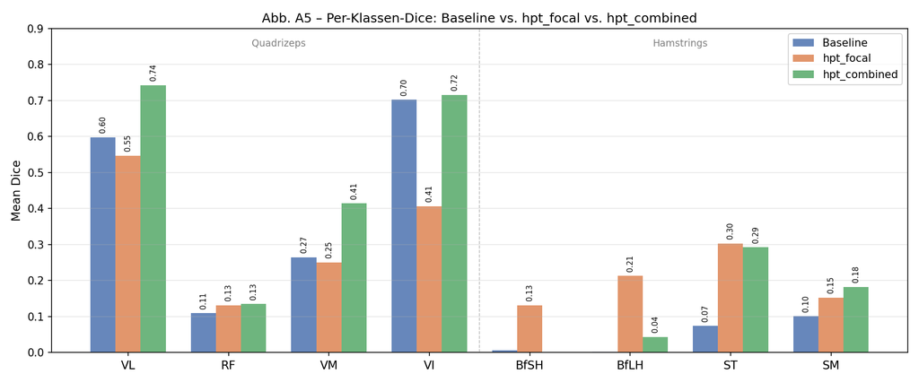

```python
print('Abb. A5 – Per-class Dice: Baseline vs. hpt_focal vs. hpt_combined:')
display(Image(filename=str(FIGS / 'abb_a5_per_class_dice.png'), width=900))
```

```
Abb. A6 – Confusion matrices (Baseline → hpt_focal → hpt_combined):
```

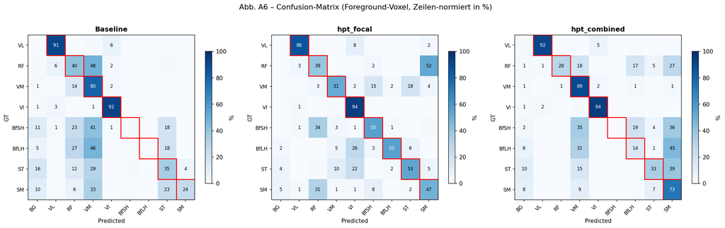

```python
print('Abb. A6 – Confusion matrices (Baseline → hpt_focal → hpt_combined):')
display(Image(filename=str(FIGS / 'abb_a6_confusion_matrices.png'), width=1100))
```

## 7 · MC Dropout Uncertainty

Expected Calibration Error (ECE) measures how well the model's confidence (from N=20 MC Dropout samples) correlates with actual accuracy. Lower = better calibrated.

```python
ece_rows = []
for key, label in EXPERIMENTS:
    eval_path = CKPT / key / 'eval_report.json'
    d = json.loads(eval_path.read_text())
    ece_vals = []
    for fold in d['per_fold']:
        for subj in fold['per_subject']:
            ece = subj.get('ece')
            if isinstance(ece, float) and not math.isnan(ece):
                ece_vals.append(ece)
    if ece_vals:
        ece_rows.append({'Experiment': label, 'Mean ECE': f'{np.mean(ece_vals):.4f}',
                         'Std ECE': f'±{np.std(ece_vals):.4f}'})

if ece_rows:
    display(pd.DataFrame(ece_rows).set_index('Experiment'))
else:
    print('ECE not recorded in eval reports.')
```

| Experiment | Mean ECE | Std ECE |
| --- | --- | --- |
| hpt_dropout | 0.0712 | ±0.0135 |

## 8 · Summary

**RQ1** (Dice ≥ 0.60): **Not achieved.** Best result: hpt_combined 0.308 (0.355 with CC). The overfit Dice of 0.90 proves model capacity; the generalization gap stems from n=10 training subjects. Clinical-grade segmentation typically requires 30–50 subjects.

**RQ2** (improvement ≥ 0.03 vs. baseline): **Achieved.** hpt_combined improves by +0.074 (without CC) and +0.089 (with CC). The combination of FocalTversky loss (penalises false negatives, β=0.7 > α=0.3) and class-balanced sampling (uniform draw over classes 1–8) is the key driver.

**Failed experiments:** hpt_augmentation (Dice 0.126) due to an anatomical augmentation bug — Axis-0/1 flips swap VL↔VM and RF↔Hamstrings, producing contradictory training signal. hpt_dropout (0.130) confirms that p=0.5 is too aggressive for n=10.